# Final Project

Diego A. Dulanto

05/06/2021

## Final Project Introduction

This project is an objective view into migration patterns from 1999-2000, specifically from Colombia, Peru, and Venezuela.

The data collected is from the national, public database of the United States Department of Justice. Immigration and Naturalization Service. I will be cleaning the data, creating summaries of the data, and displaying the difference between 1999 and 2000 using visual aids.

My hypothesis is that the most common month will be November and December and the average age will be 25-30 in 1999. Additionally, I hypothesize that the most common month will be June and July and the age will increase to 30-35 in 2000.

```
## [1] "C:/Users/Diego Dulanto/OneDrive/Documents/GitHub/hw-diegodulanto/data/immigrant_data_2000.sav"
```

```
## # A tibble: 849,386 x 17
##       V1    V2        V3    V4 V5         V6       V7        V8      V9
##    <dbl> <dbl> <dbl+lbl> <dbl> <chr> <dbl+l> <dbl+lb> <dbl+lbl> <dbl+l>
##  1     7  2000 190 [Cub~    26 Unkn~ 2 [Mar~ 15 [Flo~ 189 [Mia~ 3 [Not~
##  2     4  2000 179 [Mex~    75 Mexi~ 2 [Mar~  9 [Cal~ 188 [Mer~ 3 [Not~
##  3    12  1999 179 [Mex~    75 Mexi~ 4 [Div~  9 [Cal~ 174 [Los~ 3 [Not~
##  4     7  2000 179 [Mex~    75 Mexi~ 3 [Wid~ 55 [Tex~ 260 [San~ 3 [Not~
##  5     5  2000 179 [Mex~    75 Mexi~ 3 [Wid~  9 [Cal~ 263 [San~ 3 [Not~
##  6     7  2000  62 [Chi~    15 Chin~ 1 [Sin~  9 [Cal~ 174 [Los~ 3 [Not~
##  7     4  2000  83 [Phi~    31 Phil~ 2 [Mar~  9 [Cal~ 266 [San~ 3 [Not~
##  8     8  2000 179 [Mex~    70 Mexi~ 2 [Mar~ 55 [Tex~  91 [El ~ 3 [Not~
##  9     3  2000  52 [Uni~    75 Unit~ 2 [Mar~ 31 [Mic~ 212 [Non~ 1 [Iss~
## 10    11  1999 218 [Col~    71 Colo~ 3 [Wid~ 15 [Flo~ 189 [Mia~ 3 [Not~
## # ... with 849,376 more rows, and 8 more variables: V10 <dbl+lbl>,
## #   V11 <dbl+lbl>, V12 <chr>, V13 <dbl+lbl>, V14 <dbl+lbl>, V15 <dbl>,
## #   V16 <dbl+lbl>, V17 <dbl+lbl>
```

## Data Cleaning

First, I will be renaming the variables from the dataset. Right now, the dataset uses variables named V# (i.e., V1, V2, V3, etc.). I will be renaming the variables as such:

V1 - Month of Admission

V2 - Year of Admission

V3 - Country of Birth

V4 - Age

V5 - Country of Last Permanent Residence

V6 - Marital Status

V7 - State of Intended Residence

V8 - Metropolitan Area of Intended Residence

V9 - Labor Certification

v10 - Occupation

V11 - Sex

V12 - Country of Chargeability

v13 - Type of Case

V14 - Nonimmigrant Class of Entry

V15 - Nonimmigrant Year of Entry

V16 - Immigrant Class of Admission

v17 - Prinicipal Vs Derivative Class of Admission

```
## # A tibble: 849,386 x 17
##    Month_of_Admiss~ Year_of_Admissi~ Country_of_Birth   Age Country_of_Last~
##               <dbl>            <dbl>        <dbl+lbl> <dbl> <chr>
##  1                7             2000 190 [Cuba]          26 Unknown
##  2                4             2000 179 [Mexico]        75 Mexico
##  3               12             1999 179 [Mexico]        75 Mexico
##  4                7             2000 179 [Mexico]        75 Mexico
##  5                5             2000 179 [Mexico]        75 Mexico
##  6                7             2000  62 [China Peop~    15 China People Re~
##  7                4             2000  83 [Philippine~    31 Philippines
##  8                8             2000 179 [Mexico]        70 Mexico
##  9                3             2000  52 [United Kin~    75 United Kingdom
## 10               11             1999 218 [Colombia]      71 Colombia
## # ... with 849,376 more rows, and 12 more variables: Marital_Status <dbl+lbl>,
## #   State_of_Intended_Residence <dbl+lbl>,
## #   Metropolitan_Area_of_Intended_Residence <dbl+lbl>,
## #   Labor_Certification <dbl+lbl>, Occupation <dbl+lbl>, Sex <dbl+lbl>,
## #   Country_of_Chargeability <chr>, Type_of_Case <dbl+lbl>,
## #   Nonimmigrant_Class_of_Entry <dbl+lbl>, Nonimmigrant_Year_of_Entry <dbl>,
## #   Immigrant_Class_of_Admission <dbl+lbl>,
## #   Principal_Vs_Derivative_Class_of_Admission <dbl+lbl>
```

Now that I have renamed the variables appropriately, I can start summarizing the data for analysis. I will be summarizing the data for Colombia, Peru, and Venezuela. I will group these countries by year, so that I can distinguish the differences between 1999 and 2000. The specific differences I will be analyzing is the average age and common month immigrants from these countries enter the US.

```r
# Summarizing Data

colombia_averages <- immigrant_data %>%
  filter(Country_of_Birth == 218) %>%
  group_by(Year_of_Admission) %>%
  summarise(
    Age = mean(Age, na.rm = TRUE),
    Month = Mode(Month_of_Admission, na.rm = TRUE))

peru_averages <- immigrant_data %>%
  filter(Country_of_Birth == 224) %>%
  group_by(Year_of_Admission) %>%
  summarise(
    Age = mean(Age, na.rm = TRUE),
    Month = Mode(Month_of_Admission, na.rm = TRUE))

venezuela_averages <- immigrant_data %>%
  filter(Country_of_Birth == 227) %>%
  group_by(Year_of_Admission) %>%
  summarise(
    Age = mean(Age, na.rm = TRUE),
    Month = Mode(Month_of_Admission, na.rm = TRUE))


print(colombia_averages)
```

```
## # A tibble: 2 x 3
##   Year_of_Admission   Age Month
## *             <dbl> <dbl> <dbl>
## 1              1999  30.8    12
## 2              2000  32.9     5
```

```r
print(peru_averages)
```

```
## # A tibble: 2 x 3
##   Year_of_Admission   Age Month
## *             <dbl> <dbl> <dbl>
## 1              1999  33.7    12
## 2              2000  34.4     3
```

```r
print(venezuela_averages)
```

```
## # A tibble: 2 x 3
##   Year_of_Admission   Age Month
## *             <dbl> <dbl> <dbl>
## 1              1999  27.4    12
## 2              2000  28.5     6
```

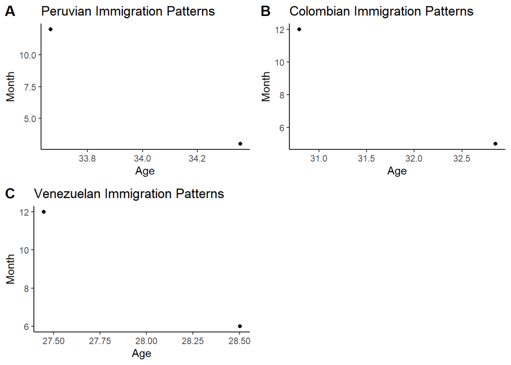